# PART I : Final Project : MATH 564

Sanketkumar Patel : A20523237

2023-12-05

```r
# Clearing workspace
rm(list = ls())

# Loading necessary libraries
library(stats)
library(corrplot)
library(car)
library(glmnet)
library(DAAG)
```

#Reading Data from given txt files

```r
# For Linthall Data which is data considering all 14 variables
LINTHALL <- as.data.frame(read.table("/Users/sanketpatel/Documents/MATH 564/Project/LINTHALL.txt",header = TRUE))

# For Linth_5 Data which is with data considering 5 variable
LINTH_5 <- read.table("/Users/sanketpatel/Documents/MATH 564/Project/LINTH-5.txt",header = TRUE)

# Removing first three columns which are not necessary for the project
LINTHALL <- LINTHALL[, -c(1,2,3)]
LINTH_5 <- LINTH_5[, -c(1,2,3)]

#Printing head of loaded data to check if data loaded properly

cat("LINTH Data with all independent variable")
```

```
## LINTH Data with all independent variable
```

```r
head(LINTHALL)
```

```
##    BIO  H2S SAL  Eh7   pH  BUF      P       K      Ca      Mg      Na      Mn
## 1  676 -610  33 -290 5.00 2.34 20.238 1441.67 2150.00 5169.05 35184.5 14.2857
## 2  516 -570  35 -268 4.75 2.66 15.591 1299.19 1844.76 4358.03 28170.4  7.7285
## 3 1052 -610  32 -282 4.20 4.18 18.716 1154.27 1750.36 4041.27 26455.0 17.8066
## 4  868 -560  30 -232 4.40 3.60 22.821 1045.15 1674.36 3966.08 25072.9 49.1538
## 5 1008 -610  33 -318 5.55 1.90 37.843  521.62 3360.02 4609.39 31664.2 30.5229
## 6  436 -620  33 -308 5.05 3.22 27.381 1273.02 1811.11 4389.84 25491.7  9.7619
##        Zn      Cu    NH4
## 1 16.4524 5.02381 59.524
## 2 13.9852 4.19019 51.378
## 3 15.3276 4.79221 68.788
## 4 17.3128 4.09487 82.256
## 5 22.3312 4.60131 70.904
## 6 12.2778 4.50794 54.206
```

```r
cat("LINTH Data with only five independent variable")
```

```
## LINTH Data with only five independent variable
```

```r
head(LINTH_5)
```

```
##    BIO SAL   pH       K      Na      Zn
## 1  676  33 5.00 1441.67 35184.5 16.4524
## 2  516  35 4.75 1299.19 28170.4 13.9852
## 3 1052  32 4.20 1154.27 26455.0 15.3276
## 4  868  30 4.40 1045.15 25072.9 17.3128
## 5 1008  33 5.55  521.62 31664.2 22.3312
## 6  436  33 5.05 1273.02 25491.7 12.2778
```

#Applying Original Model to Data

```r
# Applying ordinary least square model
Linthall_model <- lm(BIO ~ H2S + SAL + Eh7 + pH + BUF + P + K + Ca + Mg + Na + Mn + Zn + Cu + NH4, data = LINTHALL)

# Displaying summary of the model
summary(Linthall_model)
```

```
##
## Call:
## lm(formula = BIO ~ H2S + SAL + Eh7 + pH + BUF + P + K + Ca +
##     Mg + Na + Mn + Zn + Cu + NH4, data = LINTHALL)
##
## Residuals:
##    Min     1Q Median     3Q    Max
## -733.2 -131.0  -38.2  160.9  962.2
##
## Coefficients:
##               Estimate Std. Error t value Pr(>|t|)
## (Intercept)  3.476e+03  3.441e+03   1.010  0.32108
## H2S          1.154e+00  3.048e+00   0.379  0.70774
## SAL         -1.923e+01  2.658e+01  -0.723  0.47539
## Eh7          2.412e+00  1.964e+00   1.228  0.22968
## pH           1.492e+02  3.300e+02   0.452  0.65480
## BUF         -1.969e+01  1.211e+02  -0.163  0.87196
## P           -6.182e+00  3.854e+00  -1.604  0.11996
## K           -1.017e+00  4.743e-01  -2.144  0.04087 *
## Ca          -6.572e-02  1.254e-01  -0.524  0.60444
## Mg          -3.667e-01  2.730e-01  -1.343  0.18996
## Na           9.986e-03  2.430e-02   0.411  0.68421
## Mn          -3.681e+00  5.513e+00  -0.668  0.50978
## Zn          -8.082e+00  2.199e+01  -0.368  0.71599
## Cu           3.739e+02  1.104e+02   3.388  0.00211 **
## NH4         -1.551e+00  3.219e+00  -0.482  0.63366
## ---
## Signif. codes:  0 '***' 0.001 '**' 0.01 '*' 0.05 '.' 0.1 ' ' 1
##
## Residual standard error: 342.1 on 28 degrees of freedom
## Multiple R-squared:  0.8225, Adjusted R-squared:  0.7338
## F-statistic:  9.27 on 14 and 28 DF,  p-value: 4.03e-07
```

**Answer of subquestion of part I: Use the ordinary least square estimation to estimate the regression coefficients.**

```r
# Print coefficients
Estimated_coefficients <- coef(Linthall_model)
cat("Estimated regression coefficients from ordinary least square estimation are as follows: ")
```

```
## Estimated regression coefficients from ordinary least square estimation are as follows:
```

```r
Estimated_coefficients
```

```
##   (Intercept)           H2S           SAL           Eh7            pH
##  3.475951e+03  1.154424e+00 -1.923048e+01  2.411990e+00  1.491615e+02
##           BUF             P             K            Ca            Mg
## -1.969088e+01 -6.181878e+00 -1.016809e+00 -6.571561e-02 -3.666687e-01
##            Na            Mn            Zn            Cu           NH4
##  9.986448e-03 -3.681407e+00 -8.081782e+00  3.738948e+02 -1.551010e+00
```

**Collinearity diagnostics Method 1 : Collinearity diagnostics using VIF**

```r
cat("\n Values of VIF for Full model without dropping any variable are as follows :\n")
```

```
##
##  Values of VIF for Full model without dropping any variable are as follows :
```

```r
vif(Linthall_model)
```

```
##     H2S     SAL     Eh7      pH     BUF       P       K      Ca      Mg      Na
##  3.1365  3.3613  1.9641 62.5640 33.4780  2.8842  7.4321 17.3430 24.4760 10.3730
##      Mn      Zn      Cu     NH4
##  6.7378 12.3910  4.8670  8.5863
```

The Variance Inflation Factor (VIF) values measures the extent to which the variance of an estimated regression coefficient increases due to collinearity among the predictor variables, the general rule is that a VIF greater than 10 is indicative of significant collinearity.

In results:

Variables with Low VIF (Below 10) are: H2S: 3.14 SAL: 3.36 Eh7: 1.96 P: 2.88 K: 7.43 Mn: 6.74 Cu: 4.87 NH4: 8.59 These variables have low VIF values, suggesting that the collinearity for these variables is not a significant.

Variables with Moderate to High VIF (Above 10) are: pH: 62.56 BUF: 33.48 Ca: 17.34 Mg: 24.48 Na: 10.37 Zn: 12.39 The variable pH has an extremely high VIF (62.56), indicating a strong correlation with the other predictors in the model. This high VIF for ‘pH’ suggests that there might be collinearity issues associated with this variable.

In Summary: As VIF for pH, BUF, Ca, Mg, Na & Zn are above 10, suggesting significant collinearity is present in the model.

**Collinearity diagnostics Method 2 : Collinearity diagnostics using Correlation matrix and Corrplot**

```r
# Making Correlation matrix
correlation_matrix <- cor(LINTHALL[, c("H2S", "SAL", "Eh7", "pH", "BUF", "P", "K", "Ca", "Mg", "Na", "Mn", "Zn", "Cu", "NH4")])

# Print correlation matrix
cat("Correlation Matrix:\n\n")
```

```
## Correlation Matrix:
```

```r
print(correlation_matrix)
```

```
##              H2S         SAL         Eh7          pH         BUF            P
## H2S  1.000000000  0.16919044  0.43043574  0.25997622 -0.36018952 -0.284926884
## SAL  0.169190441  1.00000000  0.29677133 -0.02884686 -0.04475350 -0.061205315
## Eh7  0.430435744  0.29677133  1.00000000  0.10116975 -0.16330416 -0.326211305
## pH   0.259976217 -0.02884686  0.10116975  1.00000000 -0.94628312 -0.579402500
## BUF -0.360189517 -0.04475350 -0.16330416 -0.94628312  1.00000000  0.590229598
## P   -0.284926884 -0.06120531 -0.32621130 -0.57940250  0.59022960  1.000000000
## K    0.074174687 -0.02064988  0.42784960  0.02856352 -0.08496256 -0.243725426
## Ca   0.097201058  0.08545985 -0.04580654  0.88228821 -0.79719881 -0.391781540
## Mg  -0.090801353 -0.03522234  0.29483798 -0.16570449  0.11598794 -0.008379187
## Na   0.020681564  0.14014308  0.33806297 -0.02362396 -0.08174533 -0.118907833
## Mn   0.133887351 -0.25792364 -0.11183778 -0.49905985  0.45324346  0.540700851
## Zn  -0.291303156 -0.42244895 -0.22729261 -0.73113054  0.72832130  0.660655424
## Cu   0.002390294 -0.25940344  0.10297934  0.18743933 -0.15251009 -0.070324529
## NH4 -0.423094518 -0.18180814 -0.24498334 -0.74230878  0.84817788  0.670013281
##               K          Ca           Mg          Na         Mn          Zn
## H2S  0.07417469  0.09720106 -0.090801353  0.02068156  0.1338874 -0.29130316
## SAL -0.02064988  0.08545985 -0.035222344  0.14014308 -0.2579236 -0.42244895
## Eh7  0.42784960 -0.04580654  0.294837980  0.33806297 -0.1118378 -0.22729261
## pH   0.02856352  0.88228821 -0.165704486 -0.02362396 -0.4990599 -0.73113054
## BUF -0.08496256 -0.79719881  0.115987939 -0.08174533  0.4532435  0.72832130
## P   -0.24372543 -0.39178154 -0.008379187 -0.11890783  0.5407009  0.66065542
## K    1.00000000 -0.25995624  0.864980120  0.79561935 -0.3407068  0.06992119
## Ca  -0.25995624  1.00000000 -0.419052932 -0.24813531 -0.3219787 -0.69935070
## Mg   0.86498012 -0.41905293  1.000000000  0.89847044 -0.2124322  0.35028339
## Na   0.79561935 -0.24813531  0.898470437  1.00000000 -0.3040954  0.12167888
## Mn  -0.34070683 -0.32197869 -0.212432171 -0.30409537  1.0000000  0.61377167
## Zn   0.06992119 -0.69935070  0.350283390  0.12167888  0.6137717  1.00000000
## Cu   0.69206859 -0.10498292  0.720131336  0.56872923 -0.2282375  0.20603253
## NH4 -0.12797419 -0.58149585  0.098942377 -0.12031328  0.5497977  0.72646257
##               Cu          NH4
## H2S  0.002390294 -0.423094518
## SAL -0.259403436 -0.181808141
## Eh7  0.102979342 -0.244983344
## pH   0.187439333 -0.742308779
## BUF -0.152510093  0.848177884
## P   -0.070324529  0.670013281
## K    0.692068594 -0.127974194
## Ca  -0.104982919 -0.581495852
## Mg   0.720131336  0.098942377
## Na   0.568729233 -0.120313277
## Mn  -0.228237517  0.549797670
## Zn   0.206032530  0.726462573
## Cu   1.000000000  0.008607822
## NH4  0.008607822  1.000000000
```

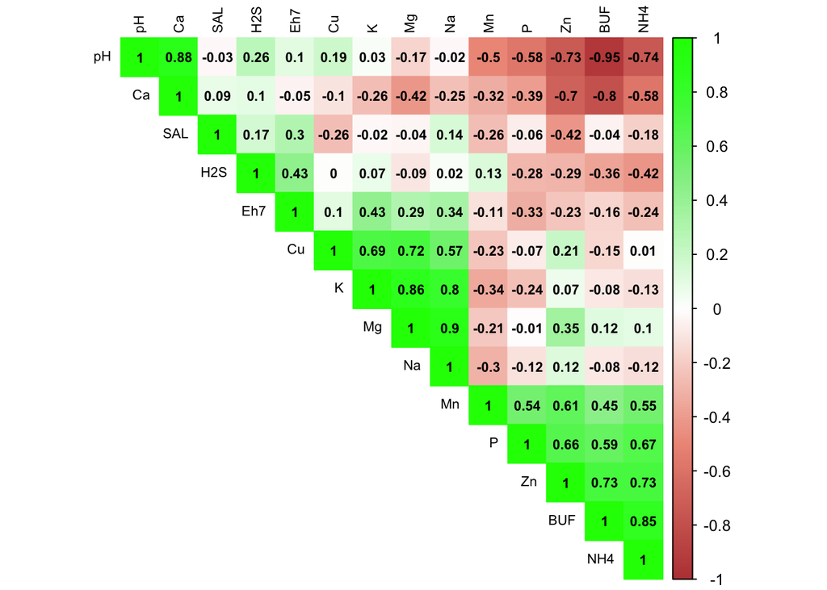

```r
# Correlation plot
corrplot(
  correlation_matrix,
  method = "color",   # Use color to represent correlations
  type = "upper",     # Display only upper triangle of the matrix
  tl.cex = 0.7,       # Adjust size of text labels
  tl.col = "black",   # Set color of text labels
  col = colorRampPalette(c("#BB4444", "#EE9988", "#FFFFFF", "lightgreen", "green"))(200),  # Custom color palette
  addCoef.col = "black",  # Set color of correlation coefficient text
  number.cex = 0.7,   # Adjust size of correlation coefficient text
  order = "hclust",   # Reorder variables using hierarchical clustering
  hclust.method = "complete"  # Hierarchical clustering method
)
```

Considering threshold value as 0.7 we can say that there are some collinearities are there in the data.

Set 1: pH and Ca

Set 2: pH and Zn

Set 3: pH and BUF

Set 4: pH and NH4

Set 5: Ca and Zn

Set 6: Ca and BUF

Set 8: Cu and Mg

Set 9: K and Mg

Set 10: K and Na

Set 11: Mg and Na

Set 12: Zn and BUF

Set 13: Zn and NH4

Set 14: BUF and NH4

following are the different sets of collinearity.

**Answer of subquestion of part I: What is the consistent conclusion you can draw from the two methods**

#Consistent Conclusion from both method can be given as follows: